# UTS MPDW

G1401211094 Hanifa Rahmacindia Nasution

2023-10-06

# Input Data

```r
library(ggplot2)
library(tsibble)
library(tseries)
library(MASS)
library(forecast)
library(TSA)
library(TTR)
library(aTSA)
library(graphics)
library(ggplot2)

Data_UTS_Fix <- rio::import("https://raw.githubusercontent.com/HanifaNasution/Praktikum-MPDW/main/Data/Data%20UTS%20Fix.csv")
str(Data_UTS_Fix)
```

```
## 'data.frame':    151 obs. of  2 variables:
##  $ Periode: int  1 2 3 4 5 6 7 8 9 10 ...
##  $ Data   : int  3980 4039 3878 3809 3829 3798 3730 3705 3701 3782 ...
```

```r
Data_UTS_Fix
```

```
##     Periode Data
## 1         1 3980
## 2         2 4039
## 3         3 3878
## 4         4 3809
## 5         5 3829
## 6         6 3798
## 7         7 3730
## 8         8 3705
## 9         9 3701
## 10       10 3782
## 11       11 3827
## 12       12 3759
## 13       13 3747
## 14       14 3666
```

[output cut: 137 more lines]

# Menambah Data Harga Jual Gas Bumi yang sudah dimodifikasi sesuai kode yang didapat di semua periode (211)

```r
datatambah <- Data_UTS_Fix[,2]+211
data1 <- cbind (Data_UTS_Fix[,1],datatambah)
```

# Pembagian Data

```r
#SPLIT DATA
train1<-data1[1:125,]
test1<-data1[126:151,]
```

# Eksplorasi

## Menjadikan data sebagai data time series

```r
data1.ts <- ts(data1[,2])


train1.ts <- ts(train1[,2])
test1.ts <- ts(test1[,2])
```

## Membuat plot time series

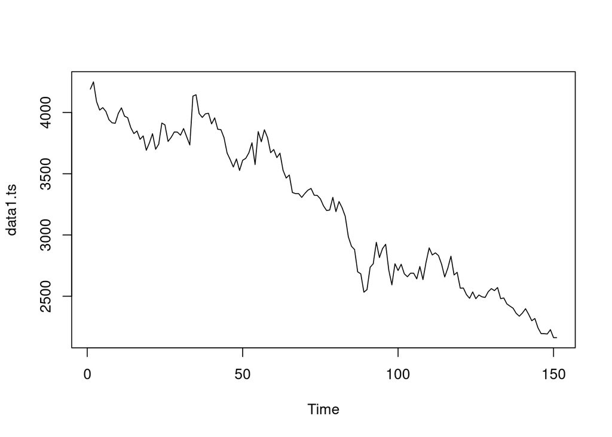

```r
plot(data1.ts)
```

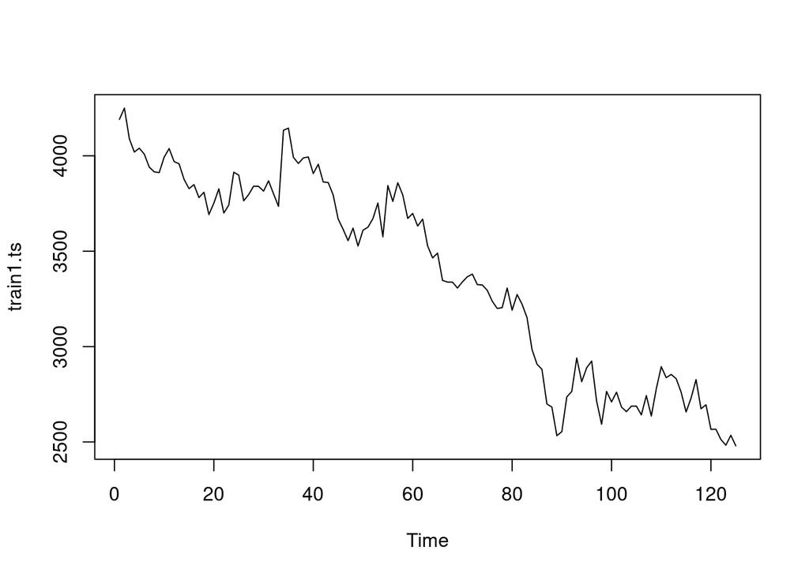

```r
plot(train1.ts)
```

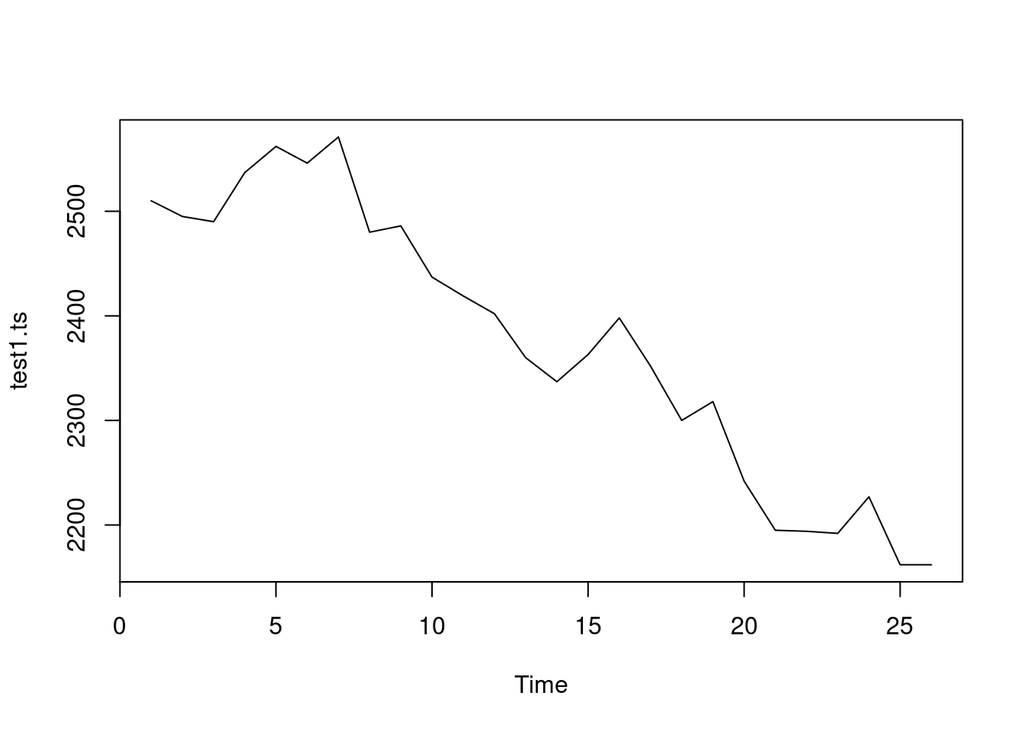

```r
plot(test1.ts)
```

Berdasarkan plot time series, tampak bahwa data memiliki komponen trend, tampak pula bahwa data tidak stasioner dalam rataan dan ragam

## Plot ACF

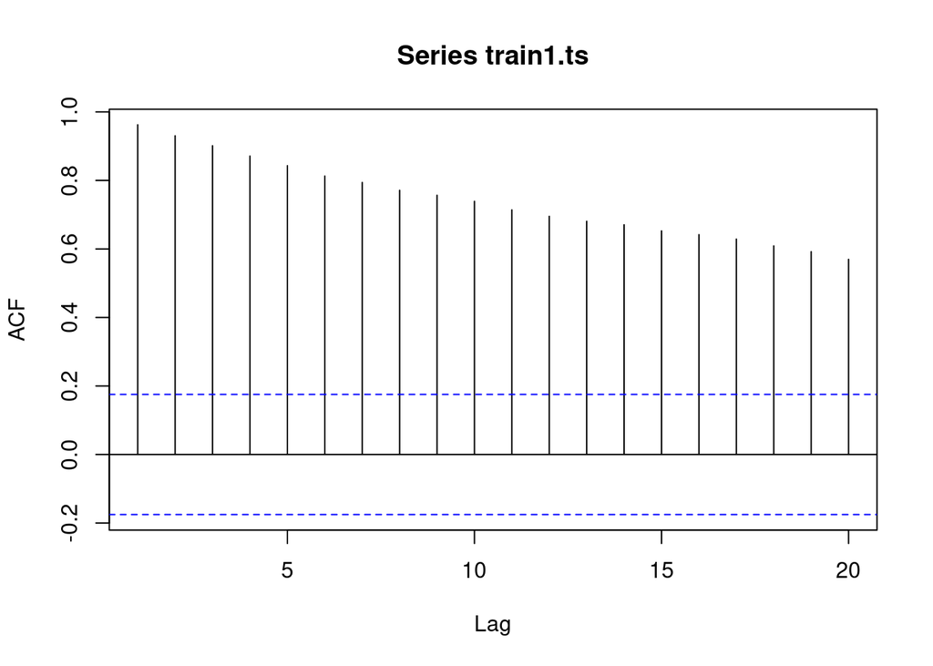

```r
acf(train1.ts)
```

Berdasarkan plot ACF, tampak bahwa data tidak stasioner dalam rataan karena terjadi *tails off slowly*

## Uji ADF

```r
tseries::adf.test(train1.ts)
```

```
##
##  Augmented Dickey-Fuller Test
##
## data:  train1.ts
## Dickey-Fuller = -2.6244, Lag order = 4, p-value = 0.3171
## alternative hypothesis: stationary
```

$H_0$ : Data tidak stasioner dalam rataan

$H_1$ : Data stasioner dalam rataan

Berdasarkan uji ADF tersebut, didapat *p-value* sebesar 0.31 yang lebih besar dari taraf nyata 5% sehingga terima $H_0$ dan menandakan bahwa data tidak stasioner dalam rataan. Hal ini sesuai dengan hasil eksplorasi menggunakan plot time series dan plot ACF.

## Uji Box Cox

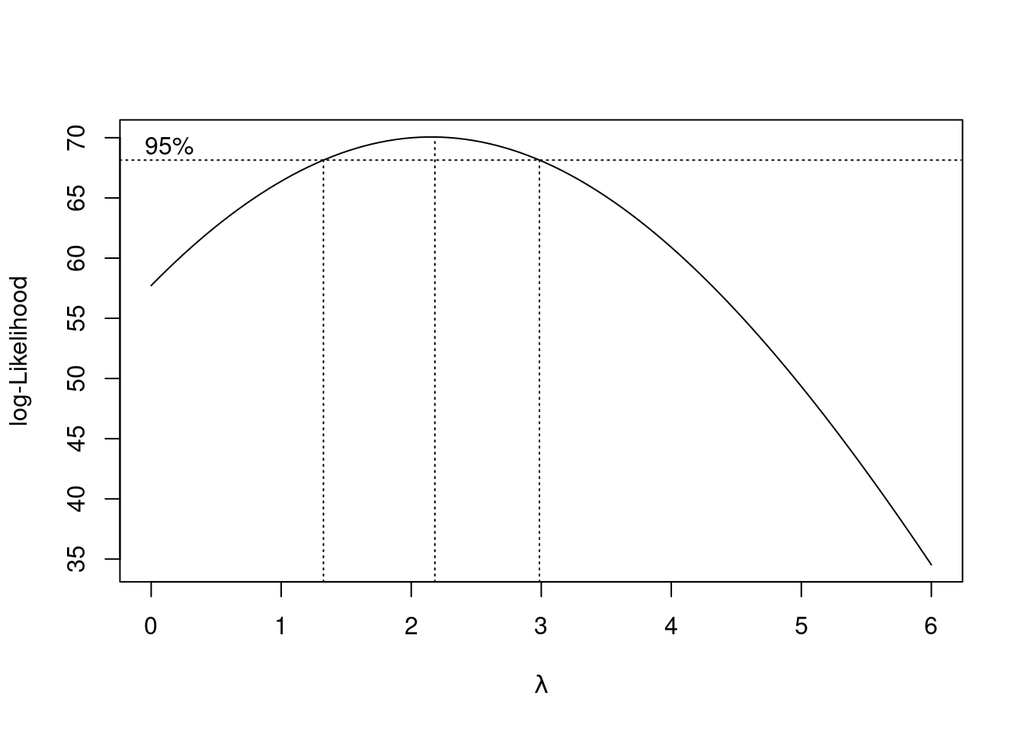

```r
index <- seq(1:125)
bc = boxcox(train1.ts~index, lambda = seq(0,6,by=1))
```

```r
#Nilai Rounded Lambda
lambda <- bc$x[which.max(bc$y)]
lambda
```

```
## [1] 2.181818
```

```r
#SK
bc$x[bc$y > max(bc$y) - 1/2 * qchisq(.95,1)]
```

```
##  [1] 1.333333 1.393939 1.454545 1.515152 1.575758 1.636364 1.696970 1.757576
##  [9] 1.818182 1.878788 1.939394 2.000000 2.060606 2.121212 2.181818 2.242424
## [17] 2.303030 2.363636 2.424242 2.484848 2.545455 2.606061 2.666667 2.727273
## [25] 2.787879 2.848485 2.909091 2.969697
```

# Penanganan Ketidakstasioneran Rataan

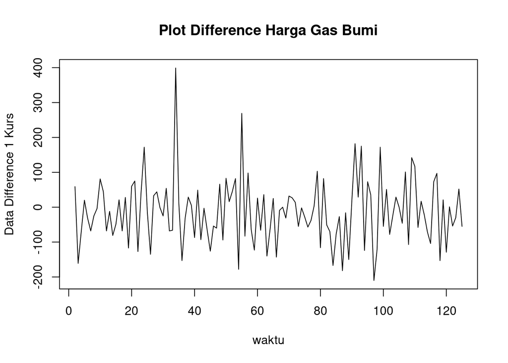

```r
train1.stas<-diff(train1.ts,differences = 1)
plot.ts(train1.stas, lty=1, xlab="waktu", ylab="Data Difference 1 Kurs", main="Plot Difference Harga Gas Bumi")
```

Berdasarkan plot data deret waktu, terlihat bahwa data sudah stasioner dalam rataan ditandai dengan data bergerak pada nilai tengah tertentu (tidak terdapat trend ataupun musiman pada data)

## Pembuktian kestasioneran pasca penanganan

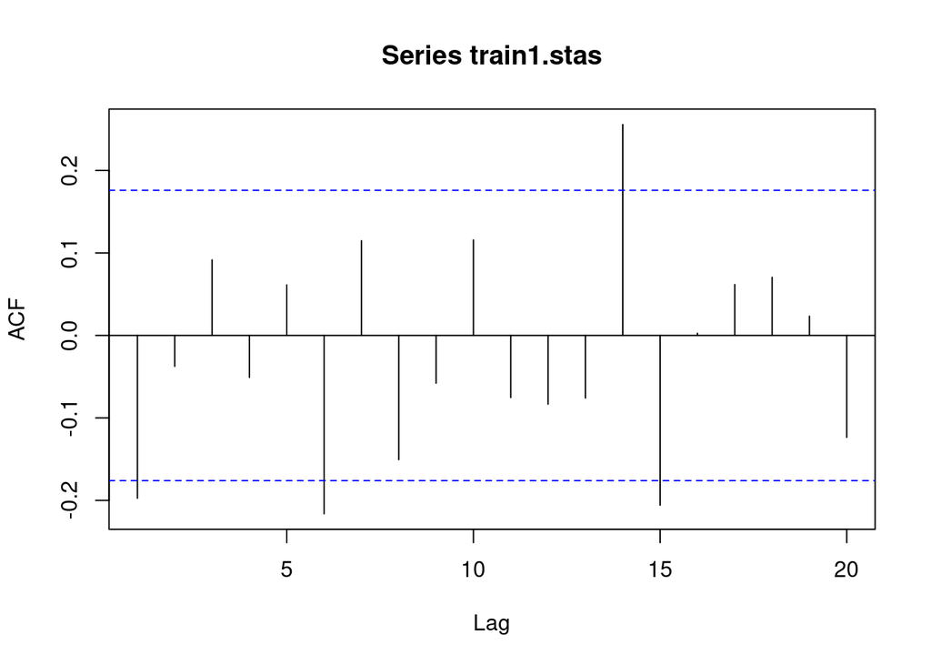

```r
acf(train1.stas)
```

berdasarkan plot ACF terbentuk gelombang sinus sehingga data telah stasioner dalam rataan.